# Chap6. Tibble

LEE EUN JU

### Library

```r
library(tidyverse)
library(gridExtra)
```

### Tibble

: data frame의 진화된 버젼

[장점]  
a) dataframe은 string을 factor로 바꾸어버리지만, tibble은 내가 인식하지 못한 순간에 바꾸지 않는다.  
b) data 보고자 할 때, row와 column 개수를 알 수 있다.

```r
as_tibble(iris)
```

```
## # A tibble: 150 x 5
##    Sepal.Length Sepal.Width Petal.Length Petal.Width Species
##           <dbl>       <dbl>        <dbl>       <dbl> <fct>
##  1          5.1         3.5          1.4         0.2 setosa
##  2          4.9         3            1.4         0.2 setosa
##  3          4.7         3.2          1.3         0.2 setosa
##  4          4.6         3.1          1.5         0.2 setosa
##  5          5           3.6          1.4         0.2 setosa
##  6          5.4         3.9          1.7         0.4 setosa
##  7          4.6         3.4          1.4         0.3 setosa
##  8          5           3.4          1.5         0.2 setosa
##  9          4.4         2.9          1.4         0.2 setosa
## 10          4.9         3.1          1.5         0.1 setosa
## # ... with 140 more rows
```

```r
head(data.frame(iris))
```

```
##   Sepal.Length Sepal.Width Petal.Length Petal.Width Species
## 1          5.1         3.5          1.4         0.2  setosa
## 2          4.9         3.0          1.4         0.2  setosa
## 3          4.7         3.2          1.3         0.2  setosa
## 4          4.6         3.1          1.5         0.2  setosa
## 5          5.0         3.6          1.4         0.2  setosa
## 6          5.4         3.9          1.7         0.4  setosa
```

c) dataframe은 x,y,z 모두 따로 생성해주고 만들어야 하지만 tibble은 data를 바로 생성할 수 있다.

```r
tibble(x = 1:5, y = 1, z = x^2+y)
```

```
## # A tibble: 5 x 3
##       x     y     z
##   <int> <dbl> <dbl>
## 1     1     1     2
## 2     2     1     5
## 3     3     1    10
## 4     4     1    17
## 5     5     1    26
```

d) tibble은 space, 숫자, 특수문자 등이 column name이 될 수 있다.

```r
tb <- tibble(
`:)` = "smile",
` ` = "space",
`2000` = "number"
)
tb
```

```
## # A tibble: 1 x 3
##   `:)`  ` `   `2000`
##   <chr> <chr> <chr>
## 1 smile space number
```

[tribble]  
: 간단하게 데이터 입력하고자 할 때 사용한다.

```r
tribble(
  ~x, ~y, ~z,
  #--/--/----
  "a", 2, 3.6,
  "b", 1, 8.5
)
```

```
## # A tibble: 2 x 3
##   x         y     z
##   <chr> <dbl> <dbl>
## 1 a         2   3.6
## 2 b         1   8.5
```

e) printing : tibble은 무조건 10개만 보여주지만, dataframe은 다 출력하여 어려움을 겪는다.  
=> 10개 이상 보고자 할때, print(n=15) : 15개의 행을 볼 수 있다.  
=> 모든 column을 보고자 할 때, width=Inf

```r
tibble(
  a = lubridate::now() + runif(1e3)*86400, #now : 현재 시간
  b = lubridate::today() + runif(1e3)*30,
  c = 1:1e3,
  d = runif(1e3),
  e = sample(letters, 1e3, replace=TRUE)
) -> tb
str(tb)
```

```
## tibble [1,000 x 5] (S3: tbl_df/tbl/data.frame)
##  $ a: POSIXct[1:1000], format: "2021-04-05 13:13:56" "2021-04-05 11:32:02" ...
##  $ b: Date[1:1000], format: "2021-04-26" "2021-04-26" ...
##  $ c: int [1:1000] 1 2 3 4 5 6 7 8 9 10 ...
##  $ d: num [1:1000] 0.158 0.869 0.584 0.157 0.819 ...
##  $ e: chr [1:1000] "s" "t" "u" "b" ...
```

```r
#console창
nycflights13::flights %>%
  print(n=15)
```

```
## # A tibble: 336,776 x 19
##     year month   day dep_time sched_dep_time dep_delay arr_time sched_arr_time
##    <int> <int> <int>    <int>          <int>     <dbl>    <int>          <int>
##  1  2013     1     1      517            515         2      830            819
##  2  2013     1     1      533            529         4      850            830
##  3  2013     1     1      542            540         2      923            850
##  4  2013     1     1      544            545        -1     1004           1022
##  5  2013     1     1      554            600        -6      812            837
##  6  2013     1     1      554            558        -4      740            728
##  7  2013     1     1      555            600        -5      913            854
##  8  2013     1     1      557            600        -3      709            723
##  9  2013     1     1      557            600        -3      838            846
## 10  2013     1     1      558            600        -2      753            745
## 11  2013     1     1      558            600        -2      849            851
## 12  2013     1     1      558            600        -2      853            856
## 13  2013     1     1      558            600        -2      924            917
## 14  2013     1     1      558            600        -2      923            937
## 15  2013     1     1      559            600        -1      941            910
## # ... with 336,761 more rows, and 11 more variables: arr_delay <dbl>,
## #   carrier <chr>, flight <int>, tailnum <chr>, origin <chr>, dest <chr>,
## #   air_time <dbl>, distance <dbl>, hour <dbl>, minute <dbl>, time_hour <dttm>
```

```r
is.table(nycflights13::flights) #table형태 True/False
```

```
## [1] FALSE
```

```r
nycflights13::flights %>% view() #따로 창을 열어 데이터를 볼 수 있다
```

f) subsetting : 변수 추출시, 여러 형태로 가능하다.

```r
df = tibble(
  x = runif(5),
  y = rnorm(5)
)

df$x
```

```
## [1] 0.93294372 0.67386050 0.13898846 0.74768278 0.08026398
```

```r
df[["x"]]
```

```
## [1] 0.93294372 0.67386050 0.13898846 0.74768278 0.08026398
```

```r
df %>% .$x  #파이프연산자 사용시 .$x 사용
```

```
## [1] 0.93294372 0.67386050 0.13898846 0.74768278 0.08026398
```

datafrmae화

```r
class(as.data.frame(tb))
```

```
## [1] "data.frame"
```

### My turn

1. How can you tell if an object is a tibble? (Hint: try printing mtcars, which is a regular data frame).  
   as_tibble : tibble형태로 변경  
   is_tibble : 현재 tibble형태인지 확인 -> TRUE/FALSE

```r
head(mtcars)
```

```
##                    mpg cyl disp  hp drat    wt  qsec vs am gear carb
## Mazda RX4         21.0   6  160 110 3.90 2.620 16.46  0  1    4    4
## Mazda RX4 Wag     21.0   6  160 110 3.90 2.875 17.02  0  1    4    4
## Datsun 710        22.8   4  108  93 3.85 2.320 18.61  1  1    4    1
## Hornet 4 Drive    21.4   6  258 110 3.08 3.215 19.44  1  0    3    1
## Hornet Sportabout 18.7   8  360 175 3.15 3.440 17.02  0  0    3    2
## Valiant           18.1   6  225 105 2.76 3.460 20.22  1  0    3    1
```

```r
is_tibble(as_tibble(mtcars))
```

```
## [1] TRUE
```

```r
class(nycflights13::flights) #3가지 형태가 될 수 있다.
```

```
## [1] "tbl_df"     "tbl"        "data.frame"
```

2) Compare and contrast the following operations on a data.frame and equivalent tibble. What is different? Why might the default dataframe behaviours cause you frustration?  
dataframe인 경우 : x가 없지만 x로 시작하는 변수를 다 불러와 어려움을 겪는다.  
tibble인 경우 : 정확한 변수명을 불러와야지만 출력된다.

```r
df = data.frame(abc=1, xyz="a")
df$x
```

```
## [1] "a"
```

```r
df[, "xyz"]
```

```
## [1] "a"
```

```r
df[, c("abc", "xyz")]
```

```
##   abc xyz
## 1   1   a
```

```r
tbl = as_tibble(df)
tbl$x
```

[output not shown]

3) Practice referring to non-syntactic names in the following data frame by:  
3-1. Extracting the variable called 1.  
3-2. Plotting a scatterplot of 1 vs 2.  
3-2. Creating a new column called 3 which is 2 divided by 1.  
3-4. Renaming the columns to one, two and three.

```r
tb = tibble(`1` = 1:10,
            `2` = `1`*2 + rnorm(length(`1`)))

#3-1 tb$1 로는 출력되지 않는다.
tb[["1"]]
```

```
##  [1]  1  2  3  4  5  6  7  8  9 10
```

```r
tb$'1'
```

```
##  [1]  1  2  3  4  5  6  7  8  9 10
```

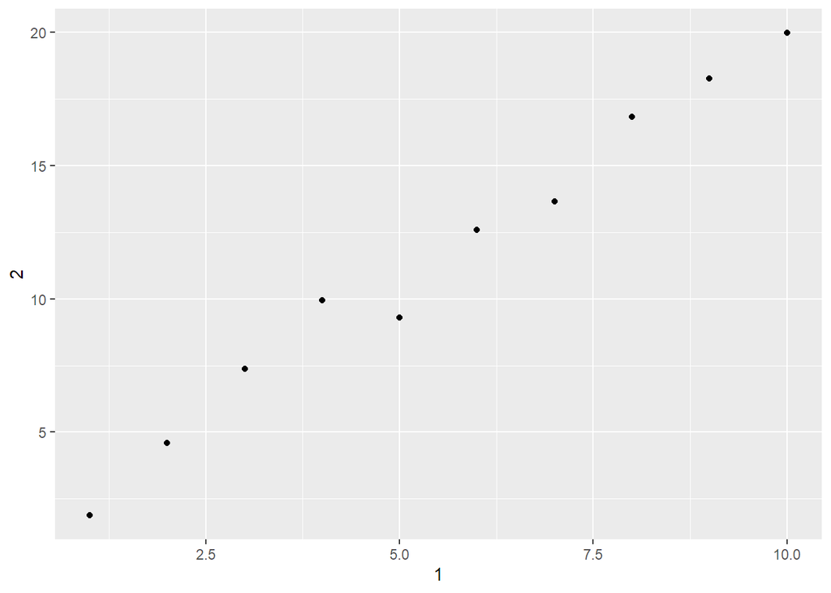

```r
#3-2 ``을 이용하여 변수 불러온다.
tb %>% ggplot() + geom_point(aes(x=`1`,y=`2`))
```

```r
#3-3
tb[["3"]] = tb$`2`/tb$`1`
mutate(tb, `3`=`2`/`1`) -> tb

#3-4
tb2 = rename(tb, one='1', two='2', three='3')
```

4) What does tibble::enframe() do? When might you use it?  
enframe : 데이터를 간략하게 만들고자 할 때, 사용하지만 tribble로 만드는 것이 더욱 유용하다.

```r
enframe(c(a=1, b=2, c=3))
```

```
## # A tibble: 3 x 2
##   name  value
##   <chr> <dbl>
## 1 a         1
## 2 b         2
## 3 c         3
```